# TBhotspotsPostratification

Post stratification of TB prevalence

McEwen Khundi London School of Hygiene & Tropical Medicine, London, UK Malawi-Liverpool-Wellcome Clinical Research Programme, Blantyre, Malawi

October 13, 2021 Table of Contents:

## 1. Backgound

## 2. Set-up

Load all required packages for analysis.

```r
library(tidyverse)    #for data manipulation
library(pmthemes)     #for ggplot themes
library(knitr)        #for tables
library(brms)
library(here)
library(gt)
library(janitor)
library(brms)
library(tidybayes)
```

## 3. Import datasets

Import data required for the analysis.

```r
ind_xray_hts_subdata_tbcse <- readRDS(here::here("data/ind_xray_hts_subdata_tbcse.rds"))

wp_2019 <- readRDS(here::here("data/wp_2019.rds")) %>% ungroup() %>% mutate(p_pop=N_wp/sum(N_wp)) %>% mutate(cluster=as.factor(paste0("c",clust)))
```

## 4. Tidying

```r
#Checking data with missing values
ind_xray_hts_subdata_tbcse %>%
  filter(rowSums(across(everything(), ~is.na(.x))) > 0 )
```

| table_sc | pid | cluster | sex | age | tbcase | x05const |
| --- | --- | --- | --- | --- | --- | --- |
| 2 | P7000284 | c70 | Female | NA | 0 | Yes |

```r
age_levels2 <- c("16-19","20-24","25-29","30-34","35-39","40-44","45-49","50-54","55-59","60-64","65-69","70+") # includes up to 70
age_levels_hack <- c(18,22,27,32,37,42,47,52,57,62,67,72)
```

## 5. Model

```r
m1 <- readRDS(here("data/m1.rds"))
m1
```

```
##  Family: bernoulli
##   Links: mu = logit
## Formula: tbcase ~ sex + age + (1 | cluster)
##    Data: ind_xray_hts_subdata_tbcse (Number of observations: 13491)
## Samples: 4 chains, each with iter = 2000; warmup = 1000; thin = 1;
##          total post-warmup samples = 4000
##
## Group-Level Effects:
## ~cluster (Number of levels: 72)
##               Estimate Est.Error l-95% CI u-95% CI Rhat Bulk_ESS Tail_ESS
## sd(Intercept)     0.45      0.29     0.02     1.10 1.00     1565     2157
##
## Population-Level Effects:
##           Estimate Est.Error l-95% CI u-95% CI Rhat Bulk_ESS Tail_ESS
## Intercept    -5.64      0.31    -6.28    -5.05 1.00     3025     2676
## sexFemale    -0.93      0.38    -1.68    -0.20 1.00     6214     2753
## age          -0.01      0.00    -0.02     0.00 1.00     3050     2074
##
## Samples were drawn using sampling(NUTS). For each parameter, Bulk_ESS
## and Tail_ESS are effective sample size measures, and Rhat is the potential
## scale reduction factor on split chains (at convergence, Rhat = 1).
```

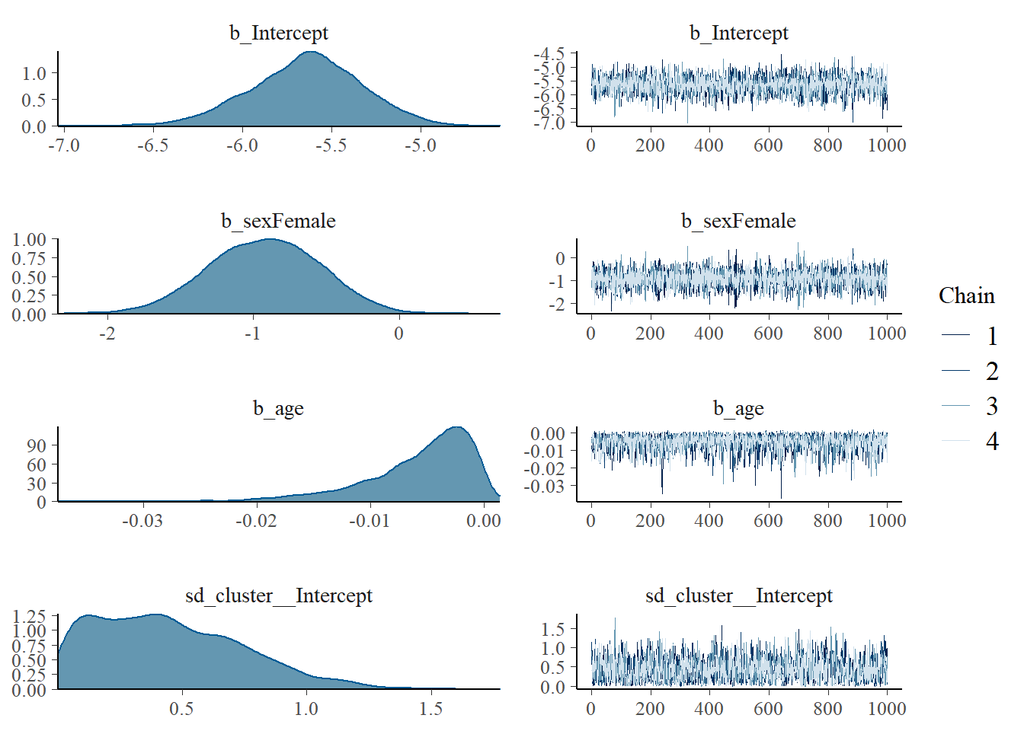

```r
plot(m1)
```

```r
# Prior names
# get_prior(formula =tbcase ~ sex + age + (1|cluster),
#           data = ind_xray_hts_subdata_tbcse , family = bernoulli())
#
# # Priors
# p1 <- c(
#   prior(normal(0,10), class=Intercept), # so this is my estimate for intercept at base case???
#   prior(normal(1,10), class="b"), #log-odds for women compared to men (see graph at top, log-odds 1 roughly equvilent to doubling)
#   prior(cauchy(0,1), sd) # can't remember/not sure what this is
# )
#
# m1 <- brm(tbcase ~ sex + age + (1|cluster),
#           data=ind_xray_hts_subdata_tbcse,
#           family=bernoulli(),
#           prior=p1,
#           chains=4,
#           cores=4)
#
# saveRDS(m1,here::here("data/m1.rds"))
```

## 6. Scaffold df

Create df for predictions

Create a scaffold df - one row per every combo of age, sex, cluster (one age at midpoint of every age group for now)

```r
# Create a scaffold df - one row per every combo of age, sex, cluster (one age at midpoint of every age group for now)
newdata_blank <- list(cluster=paste0("c",c(1:72)), age=c(18,22,27,32,37,42,47,52,57,62,67,72), sex=c("Male", "Female")) %>% expand.grid() %>% as_tibble()


a <- readRDS(here("data/a.rds"))
a <- tidybayes::add_fitted_draws(newdata=newdata_blank, model=m1)

#saveRDS(a, file = here::here("data/a.rds"))
```

So this makes sense for a summary of probability of being TB positive at any age / sex / cluster category

```r
a %>% group_by(age,sex,cluster) %>% median_qi(.value)
```

| age | sex | cluster | .value | .lower | .upper | .width | .point | .interval |
| --- | --- | --- | --- | --- | --- | --- | --- | --- |
| 18 | Male | c1 | 0.0031479877 | 0.0007138721 | 0.007677384 | 0.95 | median | qi |
| 18 | Male | c2 | 0.0032072116 | 0.0006578645 | 0.007955729 | 0.95 | median | qi |
| 18 | Male | c3 | 0.0031639721 | 0.0006413118 | 0.007931624 | 0.95 | median | qi |
| 18 | Male | c4 | 0.0031723677 | 0.0007324949 | 0.007456408 | 0.95 | median | qi |
| 18 | Male | c5 | 0.0031659407 | 0.0007197599 | 0.007396796 | 0.95 | median | qi |
| 18 | Male | c6 | 0.0031895178 | 0.0007375960 | 0.007587379 | 0.95 | median | qi |
| 18 | Male | c7 | 0.0031504123 | 0.0006566444 | 0.007567548 | 0.95 | median | qi |
| 18 | Male | c8 | 0.0031499693 | 0.0006609900 | 0.007618164 | 0.95 | median | qi |
| 18 | Male | c9 | 0.0031689638 | 0.0006901626 | 0.007923231 | 0.95 | median | qi |
| 18 | Male | c10 | 0.0031909149 | 0.0007204573 | 0.007525910 | 0.95 | median | qi |

[output cut: 1718 more lines]

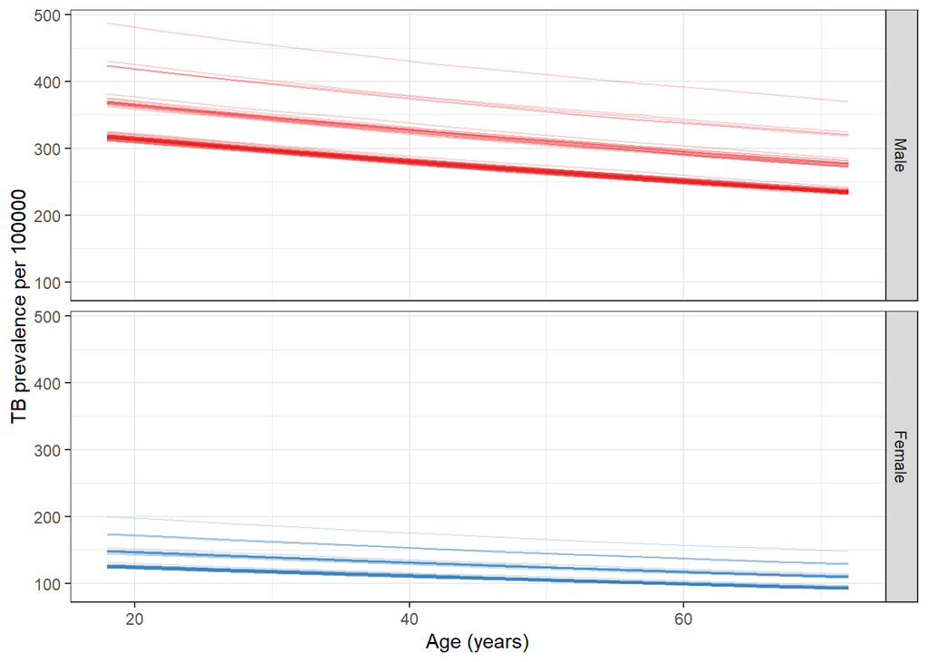

```r
a %>% group_by(age,sex,cluster) %>% median_qi(.value) %>%
  ggplot() +
  geom_path(aes(x=age, y=.value*100000, group=cluster, colour=sex), alpha=0.2) +
  facet_grid(sex~.) +
  scale_color_brewer(palette = "Set1") +
  #scale_colour_manual(values = c("cyan4", "darkorange")) +
  labs(y="TB prevalence per 100000",
       x="Age (years)") +
  theme_bw() +
  theme(legend.position = "none")
```

BUT there are two problems with “overall” TB prevalence here. (a) the CI is too wide, (b) I am pretty sure this is overall HIV prevalence (?probability) for a population where there is one person at every age-sex-cluster level.

To me this CI makes sense if you had to guess probability of any one person picked at random in Blantyre being TB positive, but it doesn’t make sense as a population prevalence (because not everyone in population is going to have extreme values).

```r
a %>% ungroup() %>% median_qi(.value)
```

| .value | .lower | .upper | .width | .point | .interval |
| --- | --- | --- | --- | --- | --- |
| 0.001792206 | 0.0003364706 | 0.006729115 | 0.95 | median | qi |

```r
0.001792206*100000; 0.0003364706*100000;    0.006729115*100000
```

```
## [1] 179.2206
```

```
## [1] 33.64706
```

```
## [1] 672.9115
```

So, not claiming this is sensible, but it is possible to take the fitted_draws df and gather a summary of each “hypothetical” one-person-per-age-sex-category population. Then can median_qi the summary…

```r
a %>% ungroup() %>% mutate(set=rep(1:4000, times=nrow(newdata_blank))) %>% # the defaults in add_fitted_draws seem to have 4000 draws per age-sex-clust category
  group_by(set) %>%
  summarise(prev=median(.value)) %>% # can take median here as there is one "person" (row) per age-sex-cluster category, so nothing to weight
  median_qi(prev)
```

| prev | .lower | .upper | .width | .point | .interval |
| --- | --- | --- | --- | --- | --- |
| 0.001782939 | 0.001016186 | 0.002691657 | 0.95 | median | qi |

```r
0.001782939*100000; 0.001016186*100000; 0.002691657*100000
```

```
## [1] 178.2939
```

```
## [1] 101.6186
```

```
## [1] 269.1657
```

^^ Still 178.29 (which I think is wrong), but CI is much smaller ( 101.6186 to 269.1657)

## 7. A scaffold from the data itself

```r
newdata_scale <- ind_xray_hts_subdata_tbcse %>%
  mutate(age = cut(age, breaks=c(15,20,25,30,35,40,45,50,55,60,65,70,Inf), right=F,  labels=age_levels_hack)) %>%
  mutate(age=as.numeric(as.character(age))) %>%
  group_by(age,sex,cluster) %>% summarise(n=n()) %>%
  right_join(newdata_blank) %>%
  mutate(n=case_when(is.na(n)~0L, T ~n)) # to make NAs into zeros
newdata_scale # so this is a dataframe with the number of people in each age-sex-cluster group ("n")
```

| age | sex | cluster | n |
| --- | --- | --- | --- |
| 18 | Male | c1 | 6 |
| 18 | Male | c10 | 6 |
| 18 | Male | c11 | 22 |
| 18 | Male | c12 | 13 |
| 18 | Male | c13 | 14 |
| 18 | Male | c14 | 12 |
| 18 | Male | c15 | 16 |
| 18 | Male | c16 | 11 |
| 18 | Male | c17 | 13 |
| 18 | Male | c18 | 13 |

[output cut: 1718 more lines]

```r
rm(a)

b <- readRDS(here("data/b.rds"))
# b <- tidybayes::add_fitted_draws(newdata=newdata_scale, model=m1)
# saveRDS(b, file = here::here("data/b.rds"))
b %>% ungroup() %>% median_qi(.value) # same as above so far - just one person for each row (have ignored "n")
```

| .value | .lower | .upper | .width | .point | .interval |
| --- | --- | --- | --- | --- | --- |
| 0.001792206 | 0.0003364706 | 0.006729115 | 0.95 | median | qi |

```r
0.001792206*100000; 0.0003364706*100000;    0.006729115*100000
```

```
## [1] 179.2206
```

```
## [1] 33.64706
```

```
## [1] 672.9115
```

Now combine with how many people are in each age-sex-cluster category (there are 4000 draws per level, so 4000 different hypothetical populations)

```r
b %>% ungroup() %>%
  mutate(set=rep(1:4000, times=nrow(newdata_blank))) %>%
  group_by(set) %>%
  mutate(p_pop=n/sum(n)) %>% ###Every sum(n) is the same try to find out from Rachael
  mutate(pp =.value * p_pop) %>%
  summarise(prev=sum(pp)) # Sothis is the overall prevalence, in 4000 different iterations of draws
```

| set | prev |
| --- | --- |
| 1 | 0.002192043 |
| 2 | 0.002094400 |
| 3 | 0.002691435 |
| 4 | 0.002430471 |
| 5 | 0.002337794 |
| 6 | 0.002448967 |
| 7 | 0.002093763 |
| 8 | 0.002422825 |
| 9 | 0.002780052 |
| 10 | 0.001712040 |

[output cut: 3990 more lines]

```r
b %>% ungroup() %>%
  mutate(set=rep(1:4000, times=nrow(newdata_blank))) %>%
  group_by(set) %>%
  mutate(p_pop=n/sum(n)) %>%
  mutate(pp =.value * p_pop) %>%
  summarise(prev=sum(pp)) %>% # Sothis is the overall prevalence, in 4000 different iterations of draws
  median_qi(prev)
```

| prev | .lower | .upper | .width | .point | .interval |
| --- | --- | --- | --- | --- | --- |
| 0.002192346 | 0.001494808 | 0.003076053 | 0.95 | median | qi |

```r
0.002192346*100000; 0.001494808*100000; 0.003076053*100000;
```

```
## [1] 219.2346
```

```
## [1] 149.4808
```

```
## [1] 307.6053
```

So this estimate ^ (219) is very similar to data, with a v small CI (149 - 307).

Could also do something similar to calculate cluster-specific prevalence; given the age and sex distribution in each cluster (in the tested dataset)

```r
c <- b %>% ungroup() %>%
  mutate(set=rep(1:4000, times=nrow(newdata_blank))) %>%
  group_by(set, cluster) %>%
  mutate(p_pop=n/sum(n)) %>%
  mutate(pp =.value * p_pop) %>%
  summarise(prev=sum(pp)) %>%
  group_by(cluster) %>%
  median_qi(prev)
c
```

| cluster | prev | .lower | .upper | .width | .point | .interval |
| --- | --- | --- | --- | --- | --- | --- |
| c1 | 0.001859521 | 0.0004448739 | 0.004343262 | 0.95 | median | qi |
| c10 | 0.001954991 | 0.0004381499 | 0.004332951 | 0.95 | median | qi |
| c11 | 0.001925857 | 0.0003774464 | 0.004440132 | 0.95 | median | qi |
| c12 | 0.002469877 | 0.0011060117 | 0.009034714 | 0.95 | median | qi |
| c13 | 0.001889280 | 0.0004198941 | 0.004309580 | 0.95 | median | qi |
| c14 | 0.001974262 | 0.0004414540 | 0.004653725 | 0.95 | median | qi |
| c15 | 0.002065223 | 0.0004192130 | 0.004580398 | 0.95 | median | qi |
| c16 | 0.001877723 | 0.0004128825 | 0.004155853 | 0.95 | median | qi |
| c17 | 0.001920233 | 0.0004368854 | 0.004324875 | 0.95 | median | qi |
| c18 | 0.002277349 | 0.0007762965 | 0.006358950 | 0.95 | median | qi |

[output cut: 62 more lines]

And plot this - is there shrinkage?

So there is shrinkage, yes!

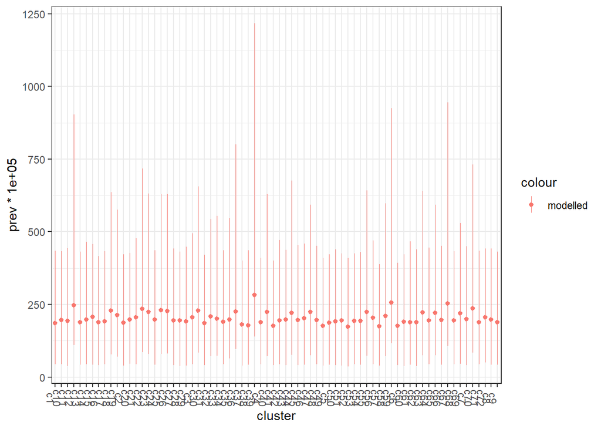

```r
# scale_clust <- scale %>% group_by(cluster) %>% summarise(n_pos=sum(hiv=="pos"), n=n()) %>% mutate(p_pos=n_pos/n) %>% filter(is.na(clust)==F)
# scale_clust$clust <- reorder(scale_clust$clust, scale_clust$p_pos)

ggplot() +
  #geom_point(aes(x=clust,y=p_pos,color="observed"), data=scale_clust) +
  geom_pointrange(aes(x=cluster, y=prev*100000, ymin=.lower*100000, ymax=.upper*100000, color="modelled"), data=c, size=0.2) +
  theme_bw() +
  theme(axis.text.x=element_text(angle=-90))
```